# Visualization_Assignment1_IPL_DATA_CASESTUDY

```python
pip install pandas
```

```python
#import all libraries
import pandas as pd
import numpy as np
import matplotlib.pyplot as plt
import seaborn as sns
import warnings
warnings.filterwarnings("ignore")
%matplotlib inline
```

Q1) Read ipl.csv file and print first 5 records.

```python
df=pd.read_csv("ipl data.csv")
df.head()
```

|  | id | season | city | date | team1 | team2 | toss_winner | toss_decision | result | dl_applied | winner | win_by_runs | win_by_wickets | player_of_match | venue | umpire1 | umpire2 | umpire3 |
| --- | --- | --- | --- | --- | --- | --- | --- | --- | --- | --- | --- | --- | --- | --- | --- | --- | --- | --- |
| 0 | 1 | 2017 | Hyderabad | 05-04-2017 | Sunrisers Hyderabad | Royal Challengers Bangalore | Royal Challengers Bangalore | field | normal | 0 | Sunrisers Hyderabad | 35 | 0 | Yuvraj Singh | Rajiv Gandhi International Stadium, Uppal | AY Dandekar | NJ Llong | NaN |
| 1 | 2 | 2017 | Pune | 06-04-2017 | Mumbai Indians | Rising Pune Supergiant | Rising Pune Supergiant | field | normal | 0 | Rising Pune Supergiant | 0 | 7 | SPD Smith | Maharashtra Cricket Association Stadium | A Nand Kishore | S Ravi | NaN |
| 2 | 3 | 2017 | Rajkot | 07-04-2017 | Gujarat Lions | Kolkata Knight Riders | Kolkata Knight Riders | field | normal | 0 | Kolkata Knight Riders | 0 | 10 | CA Lynn | Saurashtra Cricket Association Stadium | Nitin Menon | CK Nandan | NaN |
| 3 | 4 | 2017 | Indore | 08-04-2017 | Rising Pune Supergiant | Kings XI Punjab | Kings XI Punjab | field | normal | 0 | Kings XI Punjab | 0 | 6 | GJ Maxwell | Holkar Cricket Stadium | AK Chaudhary | C Shamshuddin | NaN |
| 4 | 5 | 2017 | Bangalore | 08-04-2017 | Royal Challengers Bangalore | Delhi Daredevils | Royal Challengers Bangalore | bat | normal | 0 | Royal Challengers Bangalore | 15 | 0 | KM Jadhav | M Chinnaswamy Stadium | NaN | NaN | NaN |

Q2) Check total number of columns,entries note down your findings.

```python
df.info()
```

```
<class 'pandas.core.frame.DataFrame'>
RangeIndex: 636 entries, 0 to 635
Data columns (total 18 columns):
 #   Column           Non-Null Count  Dtype
---  ------           --------------  -----
 0   id               636 non-null    int64
 1   season           636 non-null    int64
 2   city             629 non-null    object
 3   date             636 non-null    object
 4   team1            636 non-null    object
 5   team2            636 non-null    object
 6   toss_winner      636 non-null    object
 7   toss_decision    636 non-null    object
 8   result           636 non-null    object
 9   dl_applied       636 non-null    int64
 10  winner           633 non-null    object
 11  win_by_runs      636 non-null    int64
 12  win_by_wickets   636 non-null    int64
 13  player_of_match  633 non-null    object
 14  venue            636 non-null    object
 15  umpire1          635 non-null    object
 16  umpire2          635 non-null    object
 17  umpire3          0 non-null      float64
dtypes: float64(1), int64(5), object(12)
memory usage: 89.6+ KB
```

```python
# We can observe that our dataset contains 636 rows and 18 columns.
# We can also observe that there are 5 integer datatype, 1 float dataype and 12 object dataype columns in our dataset.
```

Q3) Find null values.

```python
df.isna().sum()
```

```
id                   0
season               0
city                 7
date                 0
team1                0
team2                0
toss_winner          0
toss_decision        0
result               0
dl_applied           0
winner               3
win_by_runs          0
win_by_wickets       0
player_of_match      3
venue                0
umpire1              1
umpire2              1
umpire3            636
dtype: int64
```

Q4) Drop null values of city , winner ,player_of_match,umpire1,umpire2 column.

```python
df.dropna(subset=['city','winner','player_of_match','umpire1','umpire2'],inplace=True)
```

```python
df
```

|  | id | season | city | date | team1 | team2 | toss_winner | toss_decision | result | dl_applied | winner | win_by_runs | win_by_wickets | player_of_match | venue | umpire1 | umpire2 | umpire3 |
| --- | --- | --- | --- | --- | --- | --- | --- | --- | --- | --- | --- | --- | --- | --- | --- | --- | --- | --- |
| 0 | 1 | 2017 | Hyderabad | 05-04-2017 | Sunrisers Hyderabad | Royal Challengers Bangalore | Royal Challengers Bangalore | field | normal | 0 | Sunrisers Hyderabad | 35 | 0 | Yuvraj Singh | Rajiv Gandhi International Stadium, Uppal | AY Dandekar | NJ Llong | NaN |
| 1 | 2 | 2017 | Pune | 06-04-2017 | Mumbai Indians | Rising Pune Supergiant | Rising Pune Supergiant | field | normal | 0 | Rising Pune Supergiant | 0 | 7 | SPD Smith | Maharashtra Cricket Association Stadium | A Nand Kishore | S Ravi | NaN |
| 2 | 3 | 2017 | Rajkot | 07-04-2017 | Gujarat Lions | Kolkata Knight Riders | Kolkata Knight Riders | field | normal | 0 | Kolkata Knight Riders | 0 | 10 | CA Lynn | Saurashtra Cricket Association Stadium | Nitin Menon | CK Nandan | NaN |
| 3 | 4 | 2017 | Indore | 08-04-2017 | Rising Pune Supergiant | Kings XI Punjab | Kings XI Punjab | field | normal | 0 | Kings XI Punjab | 0 | 6 | GJ Maxwell | Holkar Cricket Stadium | AK Chaudhary | C Shamshuddin | NaN |
| 5 | 6 | 2017 | Hyderabad | 09-04-2017 | Gujarat Lions | Sunrisers Hyderabad | Sunrisers Hyderabad | field | normal | 0 | Sunrisers Hyderabad | 0 | 9 | Rashid Khan | Rajiv Gandhi International Stadium, Uppal | A Deshmukh | NJ Llong | NaN |
| ... | ... | ... | ... | ... | ... | ... | ... | ... | ... | ... | ... | ... | ... | ... | ... | ... | ... | ... |
| 631 | 632 | 2016 | Raipur | 22-05-2016 | Delhi Daredevils | Royal Challengers Bangalore | Royal Challengers Bangalore | field | normal | 0 | Royal Challengers Bangalore | 0 | 6 | V Kohli | Shaheed Veer Narayan Singh International Stadium | A Nand Kishore | BNJ Oxenford | NaN |
| 632 | 633 | 2016 | Bangalore | 24-05-2016 | Gujarat Lions | Royal Challengers Bangalore | Royal Challengers Bangalore | field | normal | 0 | Royal Challengers Bangalore | 0 | 4 | AB de Villiers | M Chinnaswamy Stadium | AK Chaudhary | HDPK Dharmasena | NaN |
| 633 | 634 | 2016 | Delhi | 25-05-2016 | Sunrisers Hyderabad | Kolkata Knight Riders | Kolkata Knight Riders | field | normal | 0 | Sunrisers Hyderabad | 22 | 0 | MC Henriques | Feroz Shah Kotla | M Erasmus | C Shamshuddin | NaN |
| 634 | 635 | 2016 | Delhi | 27-05-2016 | Gujarat Lions | Sunrisers Hyderabad | Sunrisers Hyderabad | field | normal | 0 | Sunrisers Hyderabad | 0 | 4 | DA Warner | Feroz Shah Kotla | M Erasmus | CK Nandan | NaN |
| 635 | 636 | 2016 | Bangalore | 29-05-2016 | Sunrisers Hyderabad | Royal Challengers Bangalore | Sunrisers Hyderabad | bat | normal | 0 | Sunrisers Hyderabad | 8 | 0 | BCJ Cutting | M Chinnaswamy Stadium | HDPK Dharmasena | BNJ Oxenford | NaN |

625 rows × 18 columns

Q5) Drop umpire3 column as it contains more than 75% of null values.

```python
df.drop(['umpire3'],axis=1,inplace=True)
```

```python
df
```

|  | id | season | city | date | team1 | team2 | toss_winner | toss_decision | result | dl_applied | winner | win_by_runs | win_by_wickets | player_of_match | venue | umpire1 | umpire2 |
| --- | --- | --- | --- | --- | --- | --- | --- | --- | --- | --- | --- | --- | --- | --- | --- | --- | --- |
| 0 | 1 | 2017 | Hyderabad | 05-04-2017 | Sunrisers Hyderabad | Royal Challengers Bangalore | Royal Challengers Bangalore | field | normal | 0 | Sunrisers Hyderabad | 35 | 0 | Yuvraj Singh | Rajiv Gandhi International Stadium, Uppal | AY Dandekar | NJ Llong |
| 1 | 2 | 2017 | Pune | 06-04-2017 | Mumbai Indians | Rising Pune Supergiant | Rising Pune Supergiant | field | normal | 0 | Rising Pune Supergiant | 0 | 7 | SPD Smith | Maharashtra Cricket Association Stadium | A Nand Kishore | S Ravi |
| 2 | 3 | 2017 | Rajkot | 07-04-2017 | Gujarat Lions | Kolkata Knight Riders | Kolkata Knight Riders | field | normal | 0 | Kolkata Knight Riders | 0 | 10 | CA Lynn | Saurashtra Cricket Association Stadium | Nitin Menon | CK Nandan |
| 3 | 4 | 2017 | Indore | 08-04-2017 | Rising Pune Supergiant | Kings XI Punjab | Kings XI Punjab | field | normal | 0 | Kings XI Punjab | 0 | 6 | GJ Maxwell | Holkar Cricket Stadium | AK Chaudhary | C Shamshuddin |
| 5 | 6 | 2017 | Hyderabad | 09-04-2017 | Gujarat Lions | Sunrisers Hyderabad | Sunrisers Hyderabad | field | normal | 0 | Sunrisers Hyderabad | 0 | 9 | Rashid Khan | Rajiv Gandhi International Stadium, Uppal | A Deshmukh | NJ Llong |
| ... | ... | ... | ... | ... | ... | ... | ... | ... | ... | ... | ... | ... | ... | ... | ... | ... | ... |
| 631 | 632 | 2016 | Raipur | 22-05-2016 | Delhi Daredevils | Royal Challengers Bangalore | Royal Challengers Bangalore | field | normal | 0 | Royal Challengers Bangalore | 0 | 6 | V Kohli | Shaheed Veer Narayan Singh International Stadium | A Nand Kishore | BNJ Oxenford |
| 632 | 633 | 2016 | Bangalore | 24-05-2016 | Gujarat Lions | Royal Challengers Bangalore | Royal Challengers Bangalore | field | normal | 0 | Royal Challengers Bangalore | 0 | 4 | AB de Villiers | M Chinnaswamy Stadium | AK Chaudhary | HDPK Dharmasena |
| 633 | 634 | 2016 | Delhi | 25-05-2016 | Sunrisers Hyderabad | Kolkata Knight Riders | Kolkata Knight Riders | field | normal | 0 | Sunrisers Hyderabad | 22 | 0 | MC Henriques | Feroz Shah Kotla | M Erasmus | C Shamshuddin |
| 634 | 635 | 2016 | Delhi | 27-05-2016 | Gujarat Lions | Sunrisers Hyderabad | Sunrisers Hyderabad | field | normal | 0 | Sunrisers Hyderabad | 0 | 4 | DA Warner | Feroz Shah Kotla | M Erasmus | CK Nandan |
| 635 | 636 | 2016 | Bangalore | 29-05-2016 | Sunrisers Hyderabad | Royal Challengers Bangalore | Sunrisers Hyderabad | bat | normal | 0 | Sunrisers Hyderabad | 8 | 0 | BCJ Cutting | M Chinnaswamy Stadium | HDPK Dharmasena | BNJ Oxenford |

625 rows × 17 columns

```python
df.info()
```

```
<class 'pandas.core.frame.DataFrame'>
Int64Index: 625 entries, 0 to 635
Data columns (total 17 columns):
 #   Column           Non-Null Count  Dtype
---  ------           --------------  -----
 0   id               625 non-null    int64
 1   season           625 non-null    int64
 2   city             625 non-null    object
 3   date             625 non-null    object
 4   team1            625 non-null    object
 5   team2            625 non-null    object
 6   toss_winner      625 non-null    object
 7   toss_decision    625 non-null    object
 8   result           625 non-null    object
 9   dl_applied       625 non-null    int64
 10  winner           625 non-null    object
 11  win_by_runs      625 non-null    int64
 12  win_by_wickets   625 non-null    int64
 13  player_of_match  625 non-null    object
 14  venue            625 non-null    object
 15  umpire1          625 non-null    object
 16  umpire2          625 non-null    object
dtypes: int64(5), object(12)
memory usage: 87.9+ KB
```

Q6) Which city hosted most number of matches? Draw bar plot and write down your insights.

```python
df.city.value_counts()
```

```
Mumbai            85
Bangalore         63
Kolkata           61
Delhi             59
Hyderabad         49
Chennai           48
Chandigarh        46
Jaipur            33
Pune              32
Durban            15
Ahmedabad         12
Centurion         12
Visakhapatnam     11
Rajkot            10
Dharamsala         9
Johannesburg       8
Cape Town          7
Abu Dhabi          7
Ranchi             7
Port Elizabeth     7
Cuttack            7
Raipur             6
Sharjah            6
Kochi              5
Indore             5
Kanpur             4
Nagpur             3
Kimberley          3
East London        3
Bloemfontein       2
Name: city, dtype: int64
```

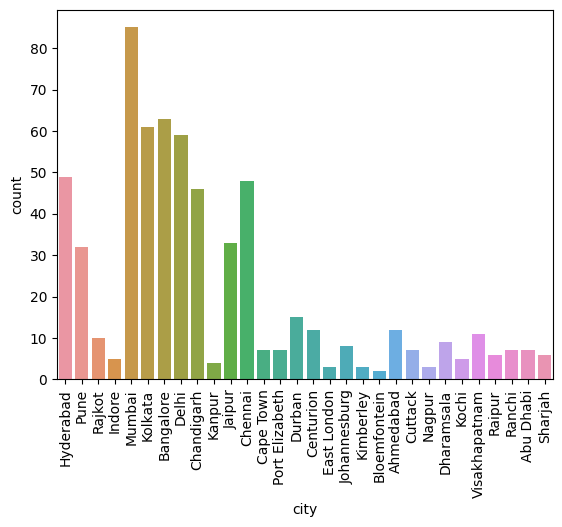

```python
sns.countplot(x=df['city'])
plt.xticks(rotation=90)
plt.show()
```

```python
# We can observe that city Mumbai has hosted the most number of matches i.e. 85.
```

Q7) Find all venue of mumbai city.

```python
venue=df[df['city']=='Mumbai']['venue'].unique()
```

```python
venue
```

```
array(['Wankhede Stadium', 'Dr DY Patil Sports Academy',
       'Brabourne Stadium'], dtype=object)
```

Q8) Now compare in which venue of mumbai most number of matches played (draw bar plot and write down insights).

```python
count=df[df['city']=='Mumbai']['venue'].value_counts()
```

```python
count
```

```
Wankhede Stadium              57
Dr DY Patil Sports Academy    17
Brabourne Stadium             11
Name: venue, dtype: int64
```

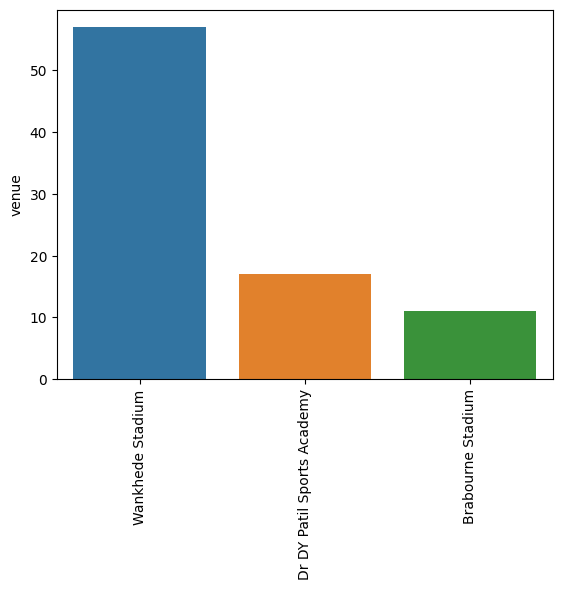

```python
sns.barplot(x=venue,y=count)
plt.xticks(rotation=90)
plt.show()
```

```python
# We can observe that Wankhede Stadium has hosted the most number of matches i.e. 57.
```

Q9) What is the preferred choice after winning a toss in mumbai?

```python
toss_decision_count=df[df['city']=='Mumbai']['toss_decision'].value_counts()
```

```python
toss_decision_count
```

```
field    51
bat      34
Name: toss_decision, dtype: int64
```

```python
# We can observe that preferred choice after winning toss in mumbai is fielding.
```

Q10) Graphical representation of above question.

```python
toss_decision=df['toss_decision'].unique()
```

```python
toss_decision
```

```
array(['field', 'bat'], dtype=object)
```

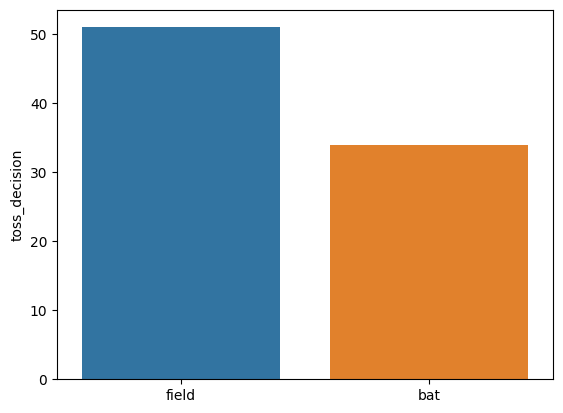

```python
sns.barplot(x=toss_decision,y=toss_decision_count)
```

Q11) Which team won most number of toss?

```python
toss_winner=df['toss_winner'].value_counts()
```

```python
toss_winner
```

```
Mumbai Indians                 83
Kolkata Knight Riders          77
Delhi Daredevils               71
Royal Challengers Bangalore    67
Kings XI Punjab                67
Chennai Super Kings            66
Rajasthan Royals               61
Deccan Chargers                43
Sunrisers Hyderabad            34
Pune Warriors                  20
Gujarat Lions                  15
Kochi Tuskers Kerala            8
Rising Pune Supergiants         7
Rising Pune Supergiant          6
Name: toss_winner, dtype: int64
```

```python
# We can observe that Mumbai Indians won most number of toss.
```

Q12) Show graphical representation of above question.

```python
toss_winner_name=df['toss_winner'].unique()
```

```python
df1=pd.DataFrame(toss_winner)
```

```python
df1
```

|  | toss_winner |
| --- | --- |
| Mumbai Indians | 83 |
| Kolkata Knight Riders | 77 |
| Delhi Daredevils | 71 |
| Royal Challengers Bangalore | 67 |
| Kings XI Punjab | 67 |
| Chennai Super Kings | 66 |
| Rajasthan Royals | 61 |
| Deccan Chargers | 43 |
| Sunrisers Hyderabad | 34 |
| Pune Warriors | 20 |
| Gujarat Lions | 15 |
| Kochi Tuskers Kerala | 8 |
| Rising Pune Supergiants | 7 |
| Rising Pune Supergiant | 6 |

```python
df1['Teams']=['Mumbai Indians','Kolkata Knight Riders','Delhi Daredevils','Royal Challengers Bangalore','kings XI Punjab','Chennai Super Kings','Rajasthan Royals',
              'Deccan Chargers','Sunrisers Hyderabad','Pune Warriors','Gujarat Lions','Kochi Tuskers Kerala','Rising Pune Supergaints','Rising Pune Supergiant']
```

```python
df1
```

|  | toss_winner | Teams |
| --- | --- | --- |
| Mumbai Indians | 83 | Mumbai Indians |
| Kolkata Knight Riders | 77 | Kolkata Knight Riders |
| Delhi Daredevils | 71 | Delhi Daredevils |
| Royal Challengers Bangalore | 67 | Royal Challengers Bangalore |
| Kings XI Punjab | 67 | kings XI Punjab |
| Chennai Super Kings | 66 | Chennai Super Kings |
| Rajasthan Royals | 61 | Rajasthan Royals |
| Deccan Chargers | 43 | Deccan Chargers |
| Sunrisers Hyderabad | 34 | Sunrisers Hyderabad |
| Pune Warriors | 20 | Pune Warriors |
| Gujarat Lions | 15 | Gujarat Lions |
| Kochi Tuskers Kerala | 8 | Kochi Tuskers Kerala |
| Rising Pune Supergiants | 7 | Rising Pune Supergaints |
| Rising Pune Supergiant | 6 | Rising Pune Supergiant |

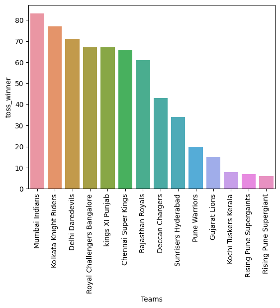

```python
sns.barplot(x=df1['Teams'],y=df1['toss_winner'])
plt.xticks(rotation=90)
plt.show()
```

Q13) Find what mumbai indians preferred after winning a toss?

```python
df[df['toss_winner']=='Mumbai Indians']['toss_decision'].value_counts()
```

```
field    44
bat      39
Name: toss_decision, dtype: int64
```

```python
# We can observe that Mumbai Indians have preferred fielding most number of times after winning toss.
```

Q14) Head to head winning count of Mumbai Indians vs Chennai Super Kings.

```python
df[((df['team1']=='Mumbai Indians')&(df['team2']=='Chennai Super Kings'))|((df['team1']=='Chennai Super Kings')&(df['team2']=='Mumbai Indians'))]['winner'].value_counts()
```

```
Mumbai Indians         12
Chennai Super Kings     9
Name: winner, dtype: int64
```

```python
# We can observe that Mumbai Indians won 12 matches while Chennai Super Kings won 9 matches.
```

Q15) Which team won most number of matches in Mumbai?

```python
df[df['city']=='Mumbai']['winner'].value_counts()
```

```
Mumbai Indians                 45
Chennai Super Kings             8
Kings XI Punjab                 5
Royal Challengers Bangalore     5
Rajasthan Royals                5
Deccan Chargers                 3
Kolkata Knight Riders           3
Pune Warriors                   3
Rising Pune Supergiant          2
Delhi Daredevils                2
Kochi Tuskers Kerala            1
Sunrisers Hyderabad             1
Rising Pune Supergiants         1
Gujarat Lions                   1
Name: winner, dtype: int64
```

```python
# We observe that Mumbai Indians won most matches in Mumbai.
```

Q16) How many times each team won the toss and won the match?

```python
df[(df['toss_winner'])==(df['winner'])]['winner'].value_counts()
```

```
Mumbai Indians                 48
Kolkata Knight Riders          44
Chennai Super Kings            42
Rajasthan Royals               34
Delhi Daredevils               33
Royal Challengers Bangalore    33
Kings XI Punjab                27
Deccan Chargers                19
Sunrisers Hyderabad            16
Gujarat Lions                  10
Rising Pune Supergiant          5
Kochi Tuskers Kerala            4
Pune Warriors                   3
Rising Pune Supergiants         3
Name: winner, dtype: int64
```

Q17) How many times each team won the toss and won the match in mumbai?

```python
df[(df['city']=='Mumbai')&((df['toss_winner'])==(df['winner']))]['winner'].value_counts()
```

```
Mumbai Indians                 26
Chennai Super Kings             5
Deccan Chargers                 3
Rajasthan Royals                2
Delhi Daredevils                2
Royal Challengers Bangalore     2
Kochi Tuskers Kerala            1
Kolkata Knight Riders           1
Gujarat Lions                   1
Name: winner, dtype: int64
```

Q18) Which venue hosted most number of matches?

```python
number_of_matches=df['venue'].value_counts()
```

```python
number_of_matches
```

```
M Chinnaswamy Stadium                                   63
Eden Gardens                                            61
Feroz Shah Kotla                                        59
Wankhede Stadium                                        57
Rajiv Gandhi International Stadium, Uppal               49
MA Chidambaram Stadium, Chepauk                         48
Punjab Cricket Association Stadium, Mohali              35
Sawai Mansingh Stadium                                  33
Dr DY Patil Sports Academy                              17
Subrata Roy Sahara Stadium                              17
Maharashtra Cricket Association Stadium                 15
Kingsmead                                               15
Sardar Patel Stadium, Motera                            12
SuperSport Park                                         12
Punjab Cricket Association IS Bindra Stadium, Mohali    11
Dr. Y.S. Rajasekhara Reddy ACA-VDCA Cricket Stadium     11
Brabourne Stadium                                       11
Saurashtra Cricket Association Stadium                  10
Himachal Pradesh Cricket Association Stadium             9
New Wanderers Stadium                                    8
Newlands                                                 7
St George's Park                                         7
Sheikh Zayed Stadium                                     7
JSCA International Stadium Complex                       7
Barabati Stadium                                         7
Shaheed Veer Narayan Singh International Stadium         6
Sharjah Cricket Stadium                                  6
Holkar Cricket Stadium                                   5
Nehru Stadium                                            5
Green Park                                               4
Vidarbha Cricket Association Stadium, Jamtha             3
De Beers Diamond Oval                                    3
Buffalo Park                                             3
OUTsurance Oval                                          2
Name: venue, dtype: int64
```

```python
df2=pd.DataFrame(number_of_matches)
```

```python
df2
```

|  | venue |
| --- | --- |
| M Chinnaswamy Stadium | 63 |
| Eden Gardens | 61 |
| Feroz Shah Kotla | 59 |
| Wankhede Stadium | 57 |
| Rajiv Gandhi International Stadium, Uppal | 49 |
| MA Chidambaram Stadium, Chepauk | 48 |
| Punjab Cricket Association Stadium, Mohali | 35 |
| Sawai Mansingh Stadium | 33 |
| Dr DY Patil Sports Academy | 17 |
| Subrata Roy Sahara Stadium | 17 |
| Maharashtra Cricket Association Stadium | 15 |
| Kingsmead | 15 |
| Sardar Patel Stadium, Motera | 12 |
| SuperSport Park | 12 |
| Punjab Cricket Association IS Bindra Stadium, Mohali | 11 |
| Dr. Y.S. Rajasekhara Reddy ACA-VDCA Cricket Stadium | 11 |
| Brabourne Stadium | 11 |
| Saurashtra Cricket Association Stadium | 10 |
| Himachal Pradesh Cricket Association Stadium | 9 |
| New Wanderers Stadium | 8 |
| Newlands | 7 |
| St George's Park | 7 |
| Sheikh Zayed Stadium | 7 |
| JSCA International Stadium Complex | 7 |
| Barabati Stadium | 7 |
| Shaheed Veer Narayan Singh International Stadium | 6 |
| Sharjah Cricket Stadium | 6 |
| Holkar Cricket Stadium | 5 |
| Nehru Stadium | 5 |
| Green Park | 4 |
| Vidarbha Cricket Association Stadium, Jamtha | 3 |
| De Beers Diamond Oval | 3 |
| Buffalo Park | 3 |
| OUTsurance Oval | 2 |

```python
venue=df['venue'].unique()
```

```python
venue
```

```
array(['Rajiv Gandhi International Stadium, Uppal',
       'Maharashtra Cricket Association Stadium',
       'Saurashtra Cricket Association Stadium', 'Holkar Cricket Stadium',
       'Wankhede Stadium', 'Eden Gardens', 'M Chinnaswamy Stadium',
       'Feroz Shah Kotla',
       'Punjab Cricket Association IS Bindra Stadium, Mohali',
       'Green Park', 'Punjab Cricket Association Stadium, Mohali',
       'Sawai Mansingh Stadium', 'MA Chidambaram Stadium, Chepauk',
       'Dr DY Patil Sports Academy', 'Newlands', "St George's Park",
       'Kingsmead', 'SuperSport Park', 'Buffalo Park',
       'New Wanderers Stadium', 'De Beers Diamond Oval',
       'OUTsurance Oval', 'Brabourne Stadium',
       'Sardar Patel Stadium, Motera', 'Barabati Stadium',
       'Vidarbha Cricket Association Stadium, Jamtha',
       'Himachal Pradesh Cricket Association Stadium', 'Nehru Stadium',
       'Dr. Y.S. Rajasekhara Reddy ACA-VDCA Cricket Stadium',
       'Subrata Roy Sahara Stadium',
       'Shaheed Veer Narayan Singh International Stadium',
       'JSCA International Stadium Complex', 'Sheikh Zayed Stadium',
       'Sharjah Cricket Stadium'], dtype=object)
```

```python
df2['venue_count']=['M Chinnaswamy Stadium','Eden Gardens','Feroz Shah Kotla','Wankhede Stadium','Rajiv Gandhi International Stadium, Uppal','MA Chidambaram Stadium, Chepauk',
              'Punjab Cricket Association Stadium, Mohali','Sawai Mansingh Stadium','Dr DY Patil Sports Academy','Subrata Roy Sahara Stadium','Maharashtra Cricket Association Stadium',
              'Kingsmead','Sardar Patel Stadium, Motera','SuperSport Park','Punjab Cricket Association IS Bindra Stadium, Mohali','Dr. Y.S. Rajasekhara Reddy ACA-VDCA Cricket Stadium',
              'Brabourne Stadium','Saurashtra Cricket Association Stadium','Himachal Pradesh Cricket Association Stadium','New Wanderers Stadium','Newlands','St Georges Park',
              'Sheikh Zayed Stadium','JSCA International Stadium Complex','Barabati Stadium','Shaheed Veer Narayan Singh International Stadium','Sharjah Cricket Stadium',
              'Holkar Cricket Stadium','Nehru Stadium','Green Park','Vidarbha Cricket Association Stadium, Jamtha','De Beers Diamond Oval','Buffalo Park','OUTsurance Oval']
```